# Parctical10

If you have 3D data you can use some libraries like plot3D, rgl, plotly to get a 3D plot.

```r
#install.packages("plotly")
#install.packages("lattice")
#install.packages("plot3D")
#install.packages("rgl")
#impliment packages within the script
library(plotly)
library(lattice)
library(plot3D)
library(rgl)
```

The following codes are examples of two basic ways of plotting contour maps. In this part we are using R studio’s volcano dataset that represents Maunga Whau (Mt Eden). This data set represents the topographic informatio on a 10x10 meter grid. A contour line map is created through the use of the contour( ) function.

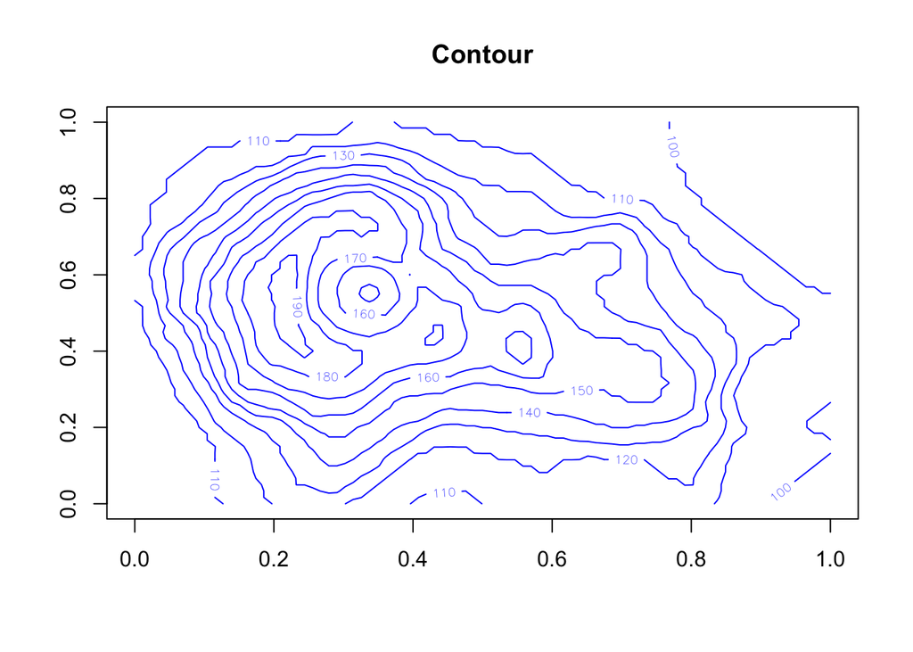

```r
#The contour line creates a basic contour map with lines in blue
contour(volcano, main = "Contour", col = "blue")
```

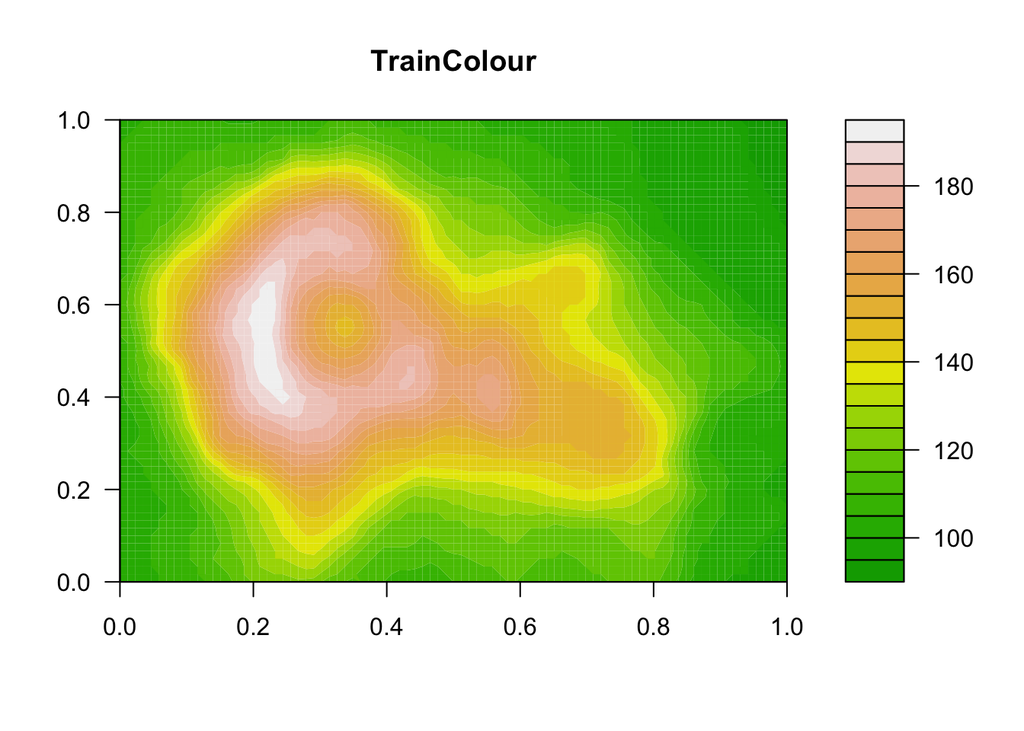

```r
#Creates a map that represents elevation change with a color gradient
filled.contour(volcano, color.palette = terrain.colors, main = "TrainColour")
```

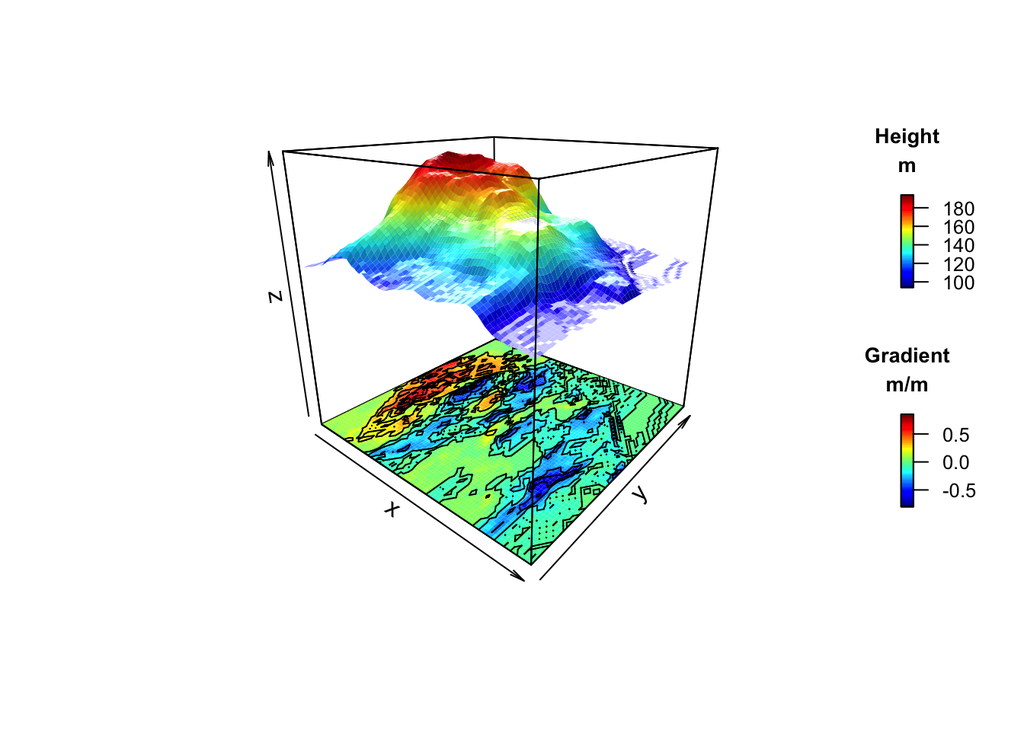

```r
#install.packages("plot3D")
library(plot3D)
#Create a composite map consisting of a 3D and a 2D contour representation
#Plot the surface based on elevation data
persp3D(z = volcano, zlim = c(-60, 200), phi = 20,
        colkey = list(length = 0.2, width = 0.4, shift = 0.15,
                      cex.axis = 0.8, cex.clab = 0.85), lighting = TRUE, lphi = 90,
        clab = c("", "Height", "m"), bty = "f", plot = FALSE)
#Create a gradient variable for longitude
canoData <- volcano[-1, ] - volcano[-nrow(volcano), ]
#Create a contour map base with the same color scheme as the 3D model
image3D(z = -60, colvar = canoData/10, add = TRUE,
        colkey = list(length = 0.2, width = 0.4, shift = -0.15,
                      cex.axis = 0.8, cex.clab = 0.85),
        clab = c("", "Gradient", "m/m"), plot = FALSE)
#Add contour lines
contour3D(z = -60 + 0.01, colvar = canoData/10, add = TRUE,
          col = "black", plot = TRUE)
```